# DATA 605 Final project

Vishal Arora

12/15/2019

# Computational Mathematics

Solutions should be provided in a format that can be shared on R Pubs and Git hub and You are also expected to make a short presentation via YouTube and post that recording to the board.

## Problem 1.

*Solution:*

Generate a random variable X

```r
# set seed value
set.seed(1)
N <- 6
X <- runif(10000, min = 1, max = N)
```

Generate a random variable Y

```r
# mean
mu <- (N+1)/2
Y <- rnorm(10000 , mean = mu)
```

*Probability*. Calculate as a minimum the below probabilities a through c. Assume the small letter “x” is estimated as the median of the X variable, and the small letter “y” is estimated as the 1st quartile of the Y variable. Interpret the meaning of all probabilities.

*5 points*

#### a. P(X>x | X>y) = 0.7875256

Solution:

```r
# first calculate x and y
x <- median(X)
y <- summary(Y)[2][[1]]


#p(A|B) = P(AB)/P(B)
sum(X>x & X > y)/sum(X>y)
```

```
## [1] 0.7875256
```

The probability of X greater than median value of X given that X is greater than first quartile of y is 0.78.

#### b. P(X>x, Y>y) = 0.3754

Solution:

```r
#P(AB)
pab <- sum(X>x & Y>y)/length(X)
```

The probability of X greater than median value of X and Y is greater than first quartile of y is 0.3754.

Solution:

```r
#p(A|B) = P(AB)/P(B)
sum(X<x & X > y)/sum(X>y)
```

```
## [1] 0.2124744
```

The probability of X less than median value of X given that X is greater than first quartile of y is 0.2124744.

*5 points.*

Investigate whether P(X>x and Y>y)=P(X>x)P(Y>y) by building a table and evaluating the marginal and joint probabilities.

Answer:

```r
tab <- c(sum(X<x & Y < y),
       sum(X < x & Y == y),
       sum(X < x & Y > y))
tab <- rbind(tab,
              c(sum(X==x & Y < y),
       sum(X == x & Y == y),
       sum(X == x & Y > y))

             )
tab <- rbind(tab,
              c(sum(X>x & Y < y),
       sum(X > x & Y == y),
       sum(X > x & Y > y))
             )
tab <- cbind(tab, tab[,1] + tab[,2] + tab[,3])
tab <- rbind(tab, tab[1,] + tab[2,] + tab[3,])
colnames(tab) <- c("Y<y", "Y=y", "Y>y", "Total")
rownames(tab) <- c("X<x", "X=x", "X>x", "Total")
knitr::kable(tab)
```

|  | Y<y | Y=y | Y>y | Total |
| --- | --- | --- | --- | --- |
| X<x | 1254 | 0 | 3746 | 5000 |
| X=x | 0 | 0 | 0 | 0 |
| X>x | 1246 | 0 | 3754 | 5000 |
| Total | 2500 | 0 | 7500 | 10000 |

Joint and marginal probability table. Now test the condition

```r
# P(X>x and Y>y)
3754/10000
```

```
## [1] 0.3754
```

```r
#P(X>x)P(Y>y)
((5000)/10000)*(7500/10000)
```

```
## [1] 0.375
```

we can see that the condition holds since P(X>x and Y>y) = 0.3754 and P(X>x)P(Y>y) = 0.375 are approximately equal.

### 5 points. Check to see if independence holds by using Fisher’s Exact Test and the Chi Square Test. What is the difference between the two? Which is most appropriate?

Solution:

Fisher’s Exact Test

```r
fisher.test(table(X>x,Y>y))
```

```
##
##  Fisher's Exact Test for Count Data
##
## data:  table(X > x, Y > y)
## p-value = 0.8716
## alternative hypothesis: true odds ratio is not equal to 1
## 95 percent confidence interval:
##  0.9202847 1.1052820
## sample estimates:
## odds ratio
##    1.00857
```

The p-value is greater than zero we don’t reject the null hypothesis. Two events are independent.

The Chi Square Test

```r
chisq.test(table(X>x,Y>y))
```

```
##
##  Pearson's Chi-squared test with Yates' continuity correction
##
## data:  table(X > x, Y > y)
## X-squared = 0.026133, df = 1, p-value = 0.8716
```

The p-value is greeter than zero we don’t reject the null hypothesis. Two events are independent.

Fisher’s exact test the null of independence of rows and columns in a contingency table with fixed marginals.

Chi-squared test tests contingency table tests and goodness-of-fit tests.

Fisher’s exact test is appropriate here. Since the contingency table are fixed here in the table.

## Problem 2

You are to register for Kaggle.com (free) and compete in the House Prices: Advanced Regression Techniques competition. https://www.kaggle.com/c/house-prices-advanced-regression-techniques . I want you to do the following.

Reading the data and construct train n test dataframes.

```r
train = read.csv("train.csv", header = TRUE)

test= read.csv("test.csv", header = TRUE)
```

Check data types and no of observations n columns using the str function.

```r
str(train)
```

```
## 'data.frame':    1460 obs. of  81 variables:
##  $ Id           : int  1 2 3 4 5 6 7 8 9 10 ...
##  $ MSSubClass   : int  60 20 60 70 60 50 20 60 50 190 ...
##  $ MSZoning     : Factor w/ 5 levels "C (all)","FV",..: 4 4 4 4 4 4 4 4 5 4 ...
##  $ LotFrontage  : int  65 80 68 60 84 85 75 NA 51 50 ...
##  $ LotArea      : int  8450 9600 11250 9550 14260 14115 10084 10382 6120 7420 ...
##  $ Street       : Factor w/ 2 levels "Grvl","Pave": 2 2 2 2 2 2 2 2 2 2 ...
##  $ Alley        : Factor w/ 2 levels "Grvl","Pave": NA NA NA NA NA NA NA NA NA NA ...
##  $ LotShape     : Factor w/ 4 levels "IR1","IR2","IR3",..: 4 4 1 1 1 1 4 1 4 4 ...
##  $ LandContour  : Factor w/ 4 levels "Bnk","HLS","Low",..: 4 4 4 4 4 4 4 4 4 4 ...
##  $ Utilities    : Factor w/ 2 levels "AllPub","NoSeWa": 1 1 1 1 1 1 1 1 1 1 ...
##  $ LotConfig    : Factor w/ 5 levels "Corner","CulDSac",..: 5 3 5 1 3 5 5 1 5 1 ...
##  $ LandSlope    : Factor w/ 3 levels "Gtl","Mod","Sev": 1 1 1 1 1 1 1 1 1 1 ...
##  $ Neighborhood : Factor w/ 25 levels "Blmngtn","Blueste",..: 6 25 6 7 14 12 21 17 18 4 ...
##  $ Condition1   : Factor w/ 9 levels "Artery","Feedr",..: 3 2 3 3 3 3 3 5 1 1 ...
```

[output cut: 67 more lines]

checking the data for missing values in columns, using the sapply function.

```r
colSums(sapply(train, is.na))
```

```
##            Id    MSSubClass      MSZoning   LotFrontage       LotArea
##             0             0             0           259             0
##        Street         Alley      LotShape   LandContour     Utilities
##             0          1369             0             0             0
##     LotConfig     LandSlope  Neighborhood    Condition1    Condition2
##             0             0             0             0             0
##      BldgType    HouseStyle   OverallQual   OverallCond     YearBuilt
##             0             0             0             0             0
##  YearRemodAdd     RoofStyle      RoofMatl   Exterior1st   Exterior2nd
##             0             0             0             0             0
##    MasVnrType    MasVnrArea     ExterQual     ExterCond    Foundation
##             8             8             0             0             0
##      BsmtQual      BsmtCond  BsmtExposure  BsmtFinType1    BsmtFinSF1
##            37            37            38            37             0
##  BsmtFinType2    BsmtFinSF2     BsmtUnfSF   TotalBsmtSF       Heating
##            38             0             0             0             0
##     HeatingQC    CentralAir    Electrical     X1stFlrSF     X2ndFlrSF
##             0             0             1             0             0
##  LowQualFinSF     GrLivArea  BsmtFullBath  BsmtHalfBath      FullBath
##             0             0             0             0             0
##      HalfBath  BedroomAbvGr  KitchenAbvGr   KitchenQual  TotRmsAbvGrd
##             0             0             0             0             0
##    Functional    Fireplaces   FireplaceQu    GarageType   GarageYrBlt
##             0             0           690            81            81
##  GarageFinish    GarageCars    GarageArea    GarageQual    GarageCond
##            81             0             0            81            81
##    PavedDrive    WoodDeckSF   OpenPorchSF EnclosedPorch    X3SsnPorch
##             0             0             0             0             0
##   ScreenPorch      PoolArea        PoolQC         Fence   MiscFeature
##             0             0          1453          1179          1406
##       MiscVal        MoSold        YrSold      SaleType SaleCondition
##             0             0             0             0             0
##     SalePrice
##             0
```

As per the missing value function above removing Right off the bat, MiscFeature, PoolQC, and Alley columns , as these columns have more than 50% data missing.

*5 points.*

Descriptive and Inferential Statistics. Provide univariate descriptive statistics and appropriate plots for the training data set. Provide a scatterplot matrix for at least two of the independent variables and the dependent variable. Derive a correlation matrix for any THREE quantitative variables in the dataset. Test the hypotheses that the correlations between each pairwise set of variables is 0 and provide a 80% confidence interval. Discuss the meaning of your analysis. Would you be worried about familywise error? Why or why not?

Rearranging the data and removing the id column from the data frame as it is not required, then using the summary function to have statistics about each individual column.

```r
nums <- unlist(lapply(train, is.numeric))
trainb<-train[ , nums]
trainc<-subset(trainb, select=-c(Id))
summary(trainc)
```

```
##    MSSubClass     LotFrontage        LotArea        OverallQual
##  Min.   : 20.0   Min.   : 21.00   Min.   :  1300   Min.   : 1.000
##  1st Qu.: 20.0   1st Qu.: 59.00   1st Qu.:  7554   1st Qu.: 5.000
##  Median : 50.0   Median : 69.00   Median :  9478   Median : 6.000
##  Mean   : 56.9   Mean   : 70.05   Mean   : 10517   Mean   : 6.099
##  3rd Qu.: 70.0   3rd Qu.: 80.00   3rd Qu.: 11602   3rd Qu.: 7.000
##  Max.   :190.0   Max.   :313.00   Max.   :215245   Max.   :10.000
##                  NA's   :259
##   OverallCond      YearBuilt     YearRemodAdd    MasVnrArea
##  Min.   :1.000   Min.   :1872   Min.   :1950   Min.   :   0.0
##  1st Qu.:5.000   1st Qu.:1954   1st Qu.:1967   1st Qu.:   0.0
##  Median :5.000   Median :1973   Median :1994   Median :   0.0
##  Mean   :5.575   Mean   :1971   Mean   :1985   Mean   : 103.7
##  3rd Qu.:6.000   3rd Qu.:2000   3rd Qu.:2004   3rd Qu.: 166.0
##  Max.   :9.000   Max.   :2010   Max.   :2010   Max.   :1600.0
##                                                NA's   :8
##    BsmtFinSF1       BsmtFinSF2        BsmtUnfSF       TotalBsmtSF
##  Min.   :   0.0   Min.   :   0.00   Min.   :   0.0   Min.   :   0.0
##  1st Qu.:   0.0   1st Qu.:   0.00   1st Qu.: 223.0   1st Qu.: 795.8
##  Median : 383.5   Median :   0.00   Median : 477.5   Median : 991.5
##  Mean   : 443.6   Mean   :  46.55   Mean   : 567.2   Mean   :1057.4
##  3rd Qu.: 712.2   3rd Qu.:   0.00   3rd Qu.: 808.0   3rd Qu.:1298.2
##  Max.   :5644.0   Max.   :1474.00   Max.   :2336.0   Max.   :6110.0
##
##    X1stFlrSF      X2ndFlrSF     LowQualFinSF       GrLivArea
##  Min.   : 334   Min.   :   0   Min.   :  0.000   Min.   : 334
##  1st Qu.: 882   1st Qu.:   0   1st Qu.:  0.000   1st Qu.:1130
##  Median :1087   Median :   0   Median :  0.000   Median :1464
##  Mean   :1163   Mean   : 347   Mean   :  5.845   Mean   :1515
##  3rd Qu.:1391   3rd Qu.: 728   3rd Qu.:  0.000   3rd Qu.:1777
##  Max.   :4692   Max.   :2065   Max.   :572.000   Max.   :5642
##
##   BsmtFullBath     BsmtHalfBath        FullBath        HalfBath
##  Min.   :0.0000   Min.   :0.00000   Min.   :0.000   Min.   :0.0000
##  1st Qu.:0.0000   1st Qu.:0.00000   1st Qu.:1.000   1st Qu.:0.0000
##  Median :0.0000   Median :0.00000   Median :2.000   Median :0.0000
##  Mean   :0.4253   Mean   :0.05753   Mean   :1.565   Mean   :0.3829
##  3rd Qu.:1.0000   3rd Qu.:0.00000   3rd Qu.:2.000   3rd Qu.:1.0000
##  Max.   :3.0000   Max.   :2.00000   Max.   :3.000   Max.   :2.0000
##
```

[output cut: 25 more lines]

```
##  Min.   :  0.000   Min.   :    0.00   Min.   : 1.000   Min.   :2006
##  1st Qu.:  0.000   1st Qu.:    0.00   1st Qu.: 5.000   1st Qu.:2007
##  Median :  0.000   Median :    0.00   Median : 6.000   Median :2008
##  Mean   :  2.759   Mean   :   43.49   Mean   : 6.322   Mean   :2008
##  3rd Qu.:  0.000   3rd Qu.:    0.00   3rd Qu.: 8.000   3rd Qu.:2009
##  Max.   :738.000   Max.   :15500.00   Max.   :12.000   Max.   :2010
##
##    SalePrice
##  Min.   : 34900
##  1st Qu.:129975
##  Median :163000
##  Mean   :180921
##  3rd Qu.:214000
##  Max.   :755000
##
```

Using plot_missing function from DataExplorer package to see the missing values for each individual columns and what is the missing data profile.

```r
library(DataExplorer)
```

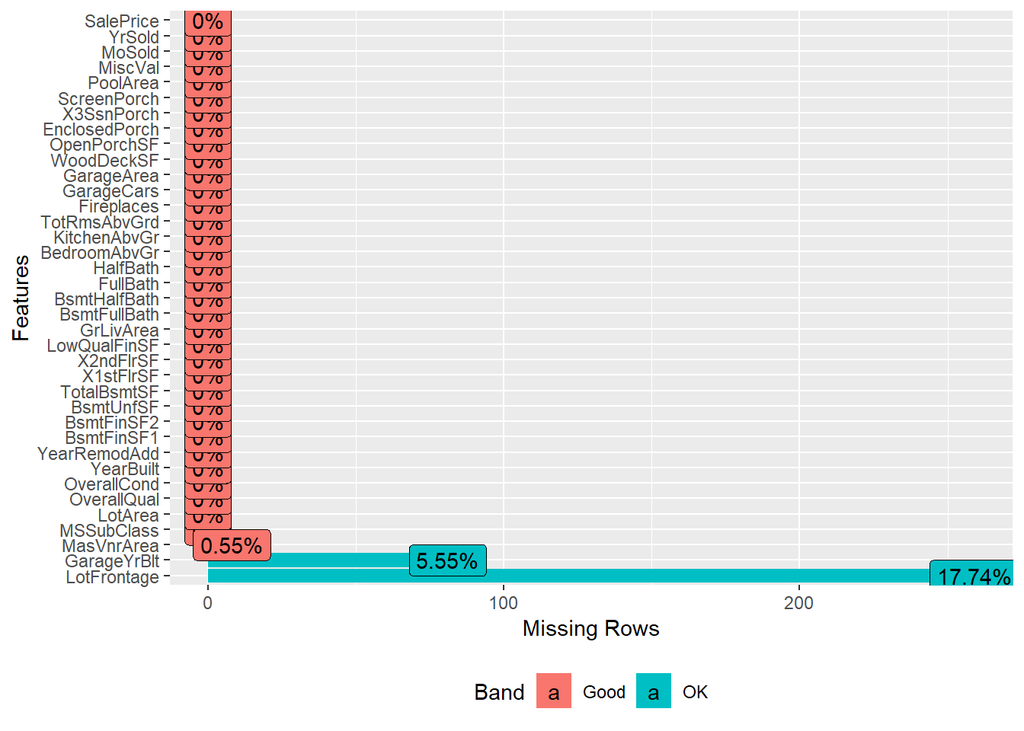

```
## $data
##           feature num_missing pct_missing Band
##  1:    MSSubClass           0 0.000000000 Good
##  2:   LotFrontage         259 0.177397260   OK
##  3:       LotArea           0 0.000000000 Good
##  4:   OverallQual           0 0.000000000 Good
##  5:   OverallCond           0 0.000000000 Good
##  6:     YearBuilt           0 0.000000000 Good
##  7:  YearRemodAdd           0 0.000000000 Good
##  8:    MasVnrArea           8 0.005479452 Good
##  9:    BsmtFinSF1           0 0.000000000 Good
## 10:    BsmtFinSF2           0 0.000000000 Good
## 11:     BsmtUnfSF           0 0.000000000 Good
## 12:   TotalBsmtSF           0 0.000000000 Good
## 13:     X1stFlrSF           0 0.000000000 Good
```

[output cut: 25 more lines]

```r
plot_missing(trainc)[1]
```

Out of the selected numerical variables, they all have less than 20% missing data. we will try to impute the missing values with the mean or mode. While there are not many interesting insights from plot_missing , below is the output from plot_histogram.

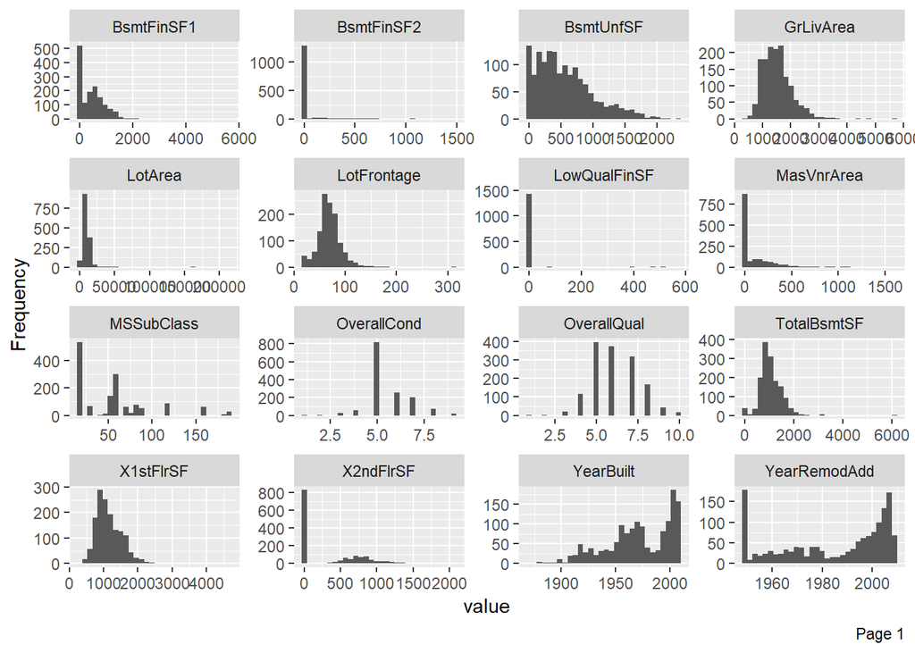

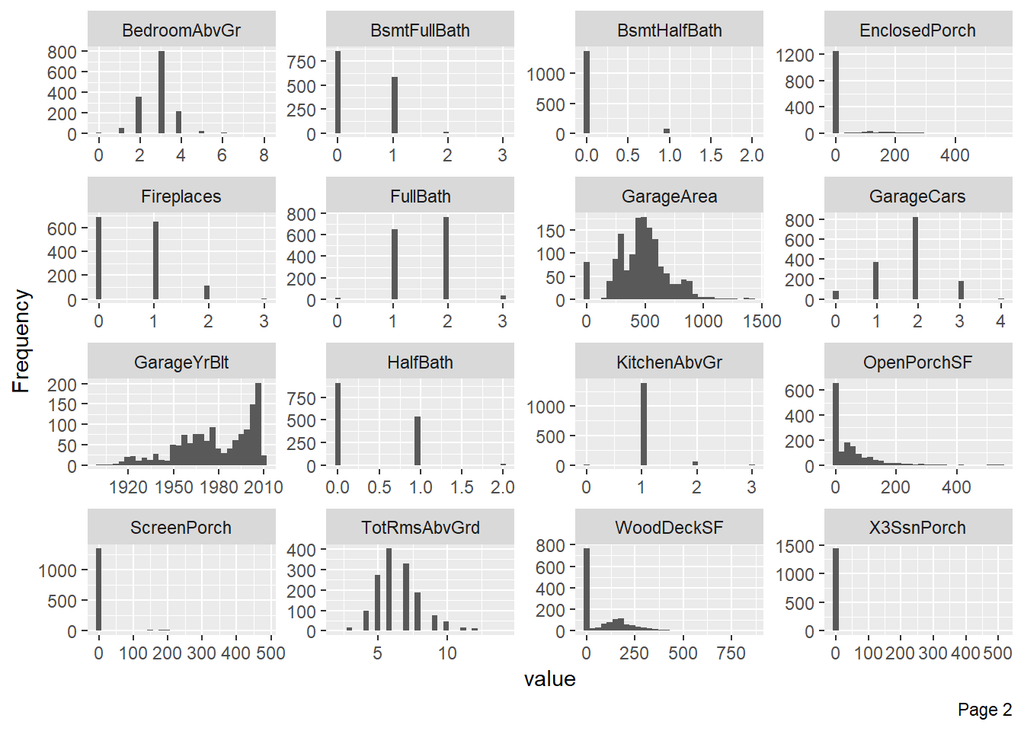

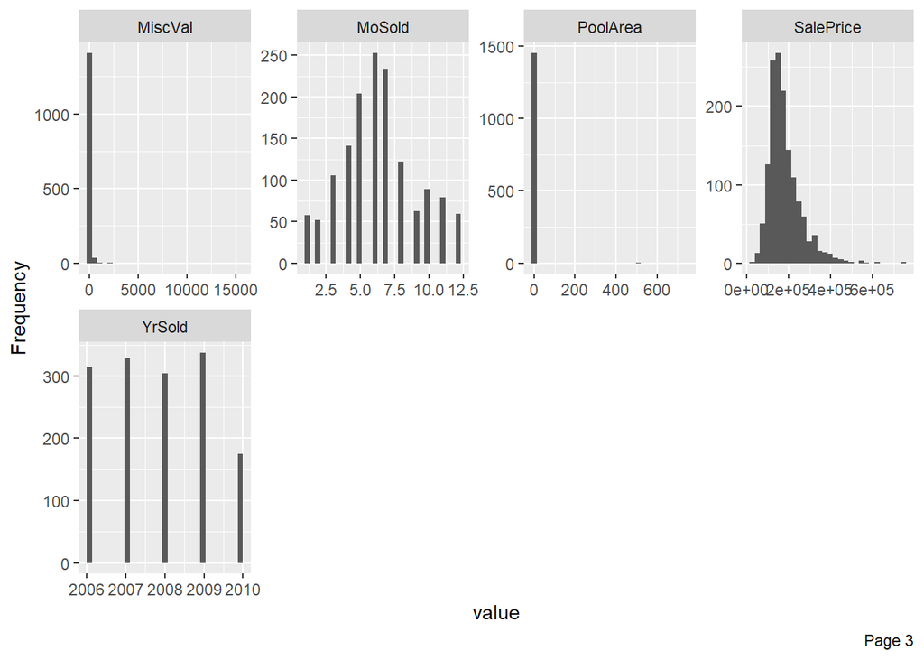

```r
plot_histogram(trainc)
```

At this point, we have much better understanding of the data distribution.Now assume we are interested in GrLivArea, and would like to build a model to predict it. Let’s plot it against all other variables.

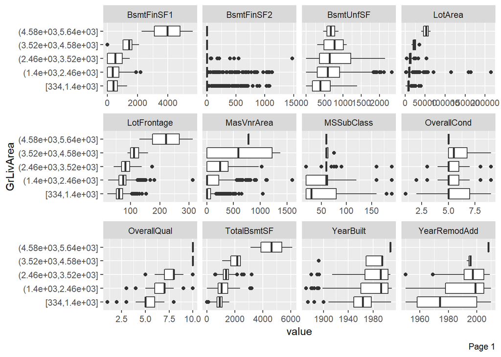

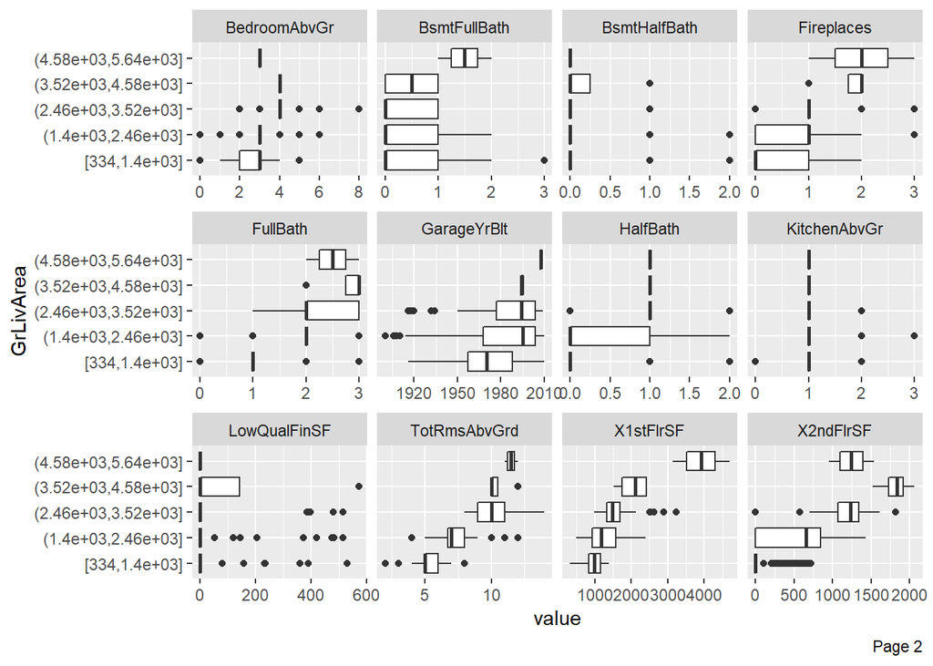

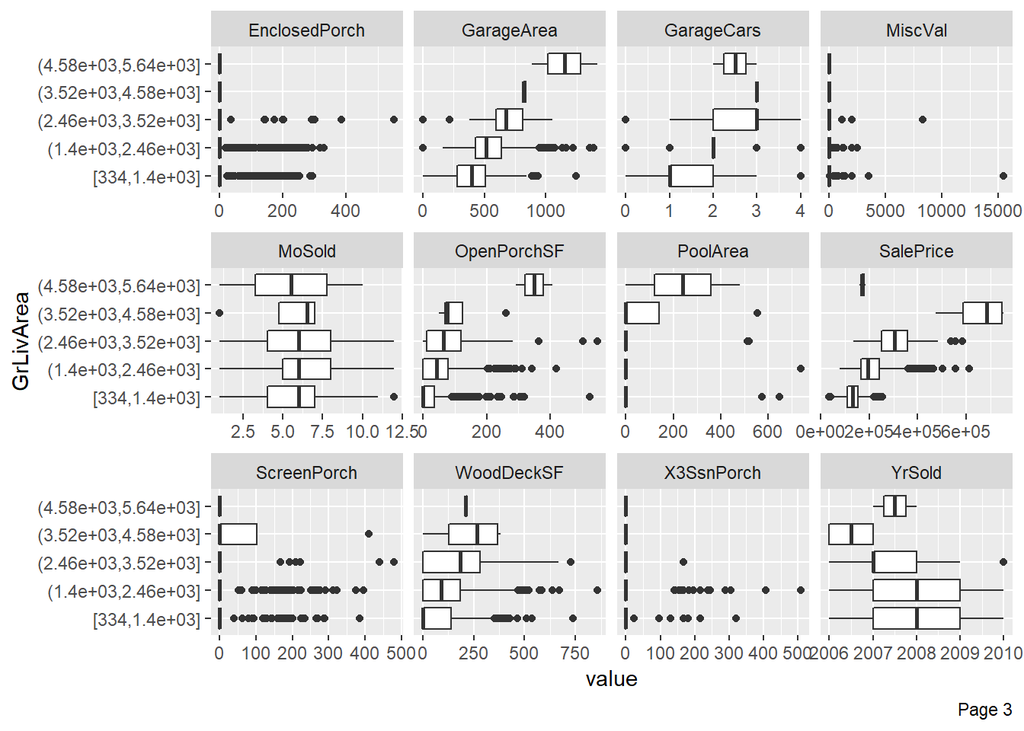

```r
plot_boxplot(trainc, by = "GrLivArea")
```

Plotting scatter plots for all variables against the response variable

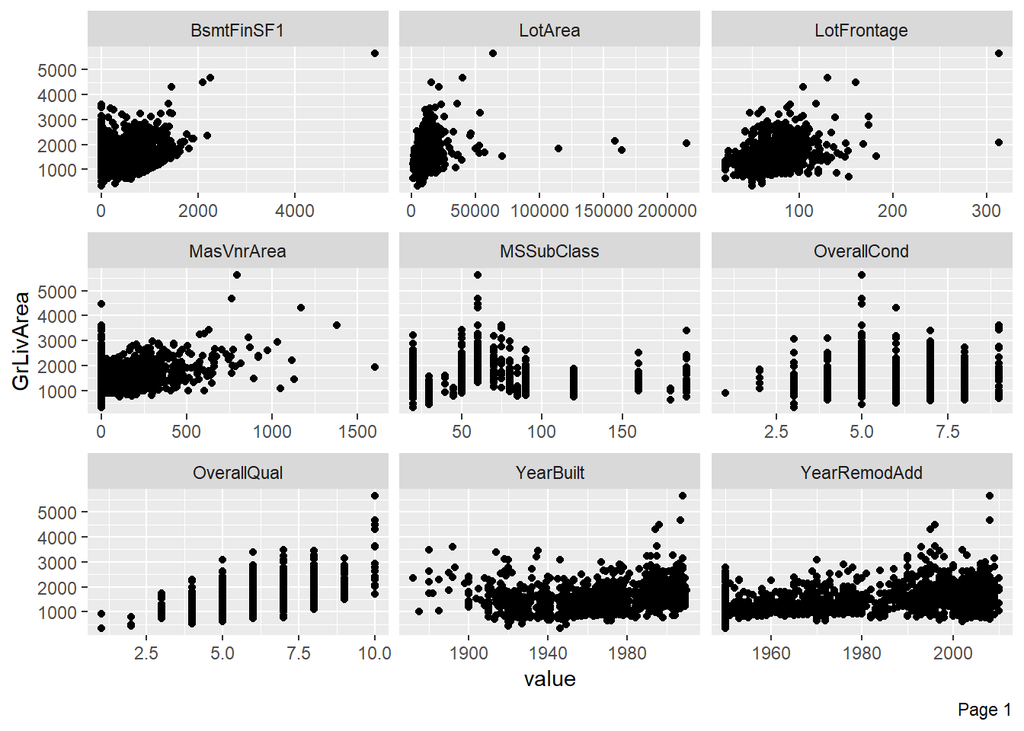

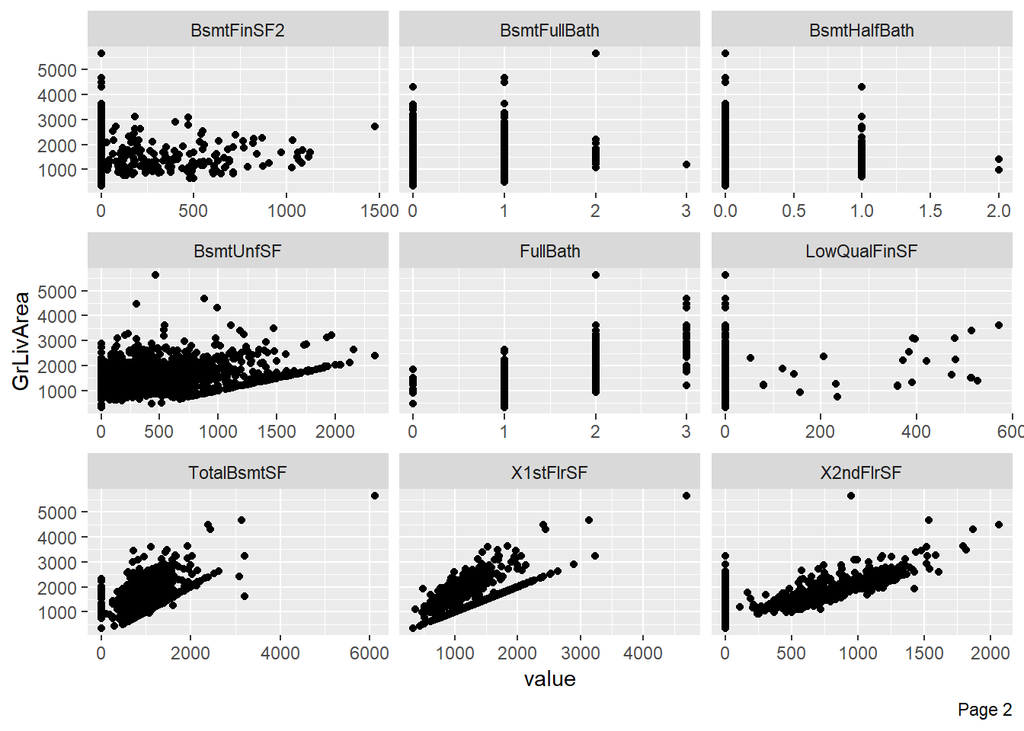

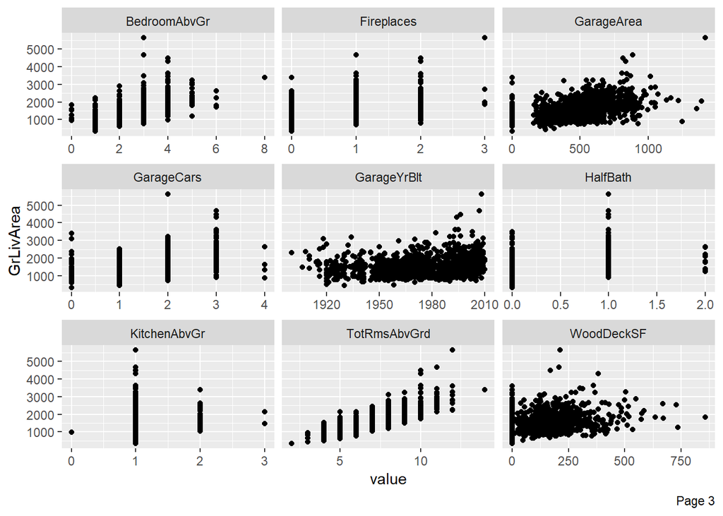

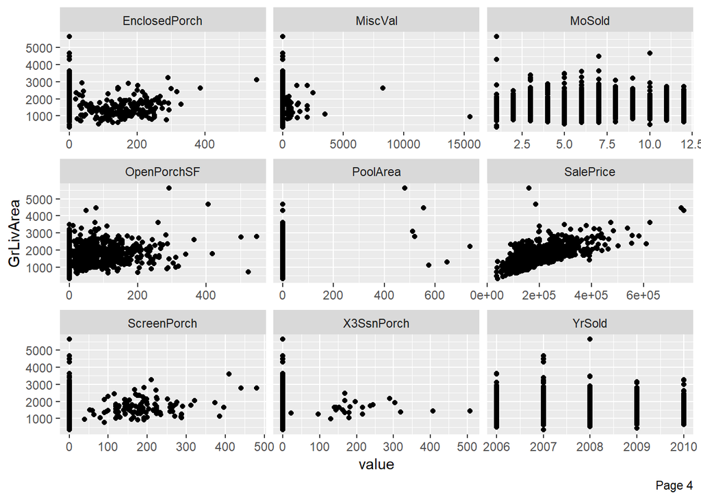

```r
plot_scatterplot(trainc,  by = "GrLivArea")
```

Plotting the correlation

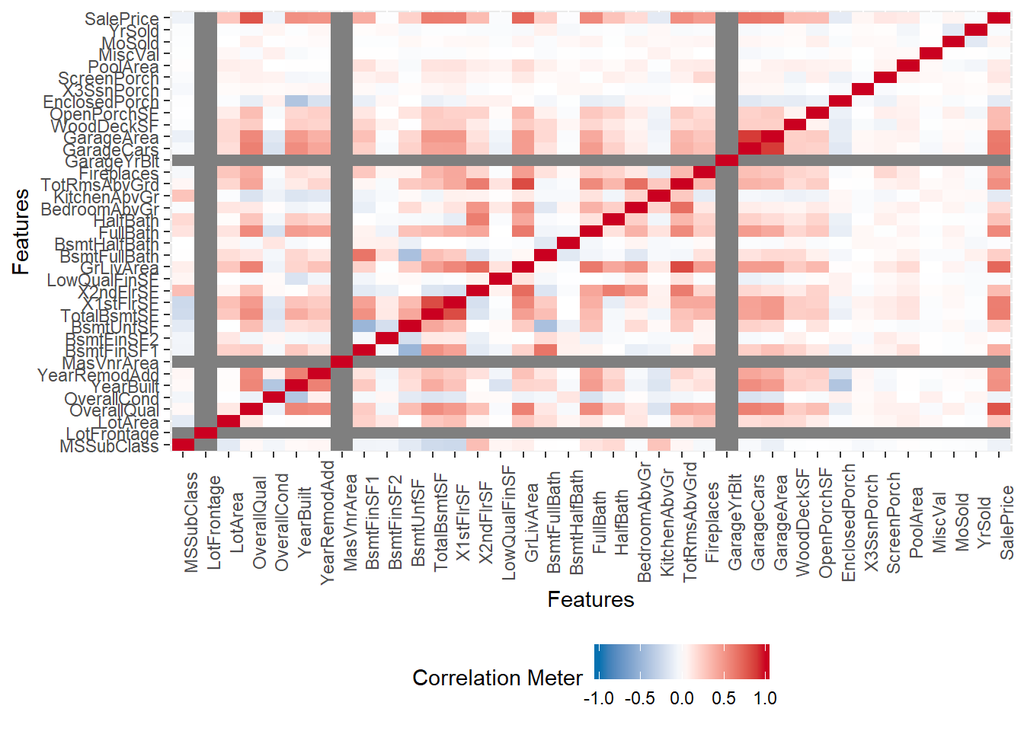

```r
plot_correlation(trainc)
```

Derive a correlation matrix for any THREE variables .Lets pick the two variables from the scatter plot and the response variable.

```r
corr_data<-subset(trainc,select=c("X1stFlrSF","LotArea", "SalePrice"))


correlation_matrix <- round(cor(corr_data),2)

# Get lower triangle of the correlation matrix
  get_lower_tri<-function(correlation_matrix){
    correlation_matrix[upper.tri(correlation_matrix)] <- NA
    return(correlation_matrix)
  }
  # Get upper triangle of the correlation matrix
  get_upper_tri <- function(correlation_matrix){
    correlation_matrix[lower.tri(correlation_matrix)]<- NA
    return(correlation_matrix)
  }

  upper_tri <- get_upper_tri(correlation_matrix)



library(reshape2)
```